# Introduction:

## Explain the properties of the chosen data set and what you will be doing with it:

There are two data sets, one of them contains all the fake news, and the other contains all the true or verified news. Using these data sets, we will create 3 working machine learning models for data classification between fake and true news, with the help of natural language processing (NLP).

## Mention the two (or more) machine learning techniques that you will be using:

We will be using 3 machine learning models:

Logistic Regression Support Vector Machine Naive Bayes

# Background:

## Describe the mechanics of the selected machine learning techniques:

### Logistic Regression:

Logistic regression is a simple yet very effective classification algorithm so it is commonly used for many binary classification tasks.Logistic regression uses an equation as the representation, very much like linear regression. Input values (x) are combined linearly using weights or coefficient values (referred to as the Greek capital letter Beta) to predict an output value (y).

### Support Vector Machine: Classification

SVM or Support Vector Machine is a linear model for classification and regression problems. It can solve linear and non-linear problems and work well for many practical problems. The idea of SVM is simple: The algorithm creates a line or a hyperplane which separates the data into classes.

### Naive Bayes:

It is a classification technique based on Bayes' Theorem with an assumption of independence among predictors. In simple terms, a Naive Bayes classifier assumes that the presence of a particular feature in a class is unrelated to the presence of any other feature.

## Describe what rescaling and normalisation are and why they are important:

Normalization is a technique for organizing data in a database. It is important that a database is normalized to minimize redundancy (duplicate data) and to ensure only related data is stored in each table. It also prevents any issues stemming from database modifications such as insertions, deletions, and updates.

## Describe what cross validation is:

Cross-Validation is a statistical method of evaluating and comparing learning algorithms by dividing data into two segments: one used to learn or train a model and the other used to validate the model. It is a resampling technique with the fundamental idea of splitting the dataset into 2 parts- training data and test data. Train data is used to train the model and the unseen test data is used for prediction. If the model performs well over the test data and gives good accuracy, it means the model hasn’t overfitted the training data and can be used for prediction. Here we split our data into K parts, let’s use K=3 for a toy example. If we have 3000 instances in our dataset, We split it into three parts, part 1, part 2 and part 3. We then build three different models, each model is trained on two parts and tested on the third. Our first model is trained on part 1 and 2 and tested on part 3. Our second model is trained to on part 1 and part 3 and tested on part 2 and so on.

## Describe what dimensionality reduction and feature selection methods are:

Feature selection is simply selecting and excluding given features without changing them. Dimensionality reduction transforms features into a lower dimension.

## Explain the quantitative measurements that you will be using to quantify the results

We will be using accuracy score as our measurement. Accuracy score is:

Accuracy Score: Accuracy is one metric for evaluating classification models. Informally, accuracy is the fraction of predictions our model got right. Formally, accuracy has the following definition:

Accuracy = [Number of correct predictions / Total number of predictions]

```python
# Importing necessary libraries.
```

```python
import numpy as np
import matplotlib.pyplot as plt
%matplotlib inline
import seaborn as sns
import pandas as pd
import warnings
warnings.filterwarnings('ignore')
```

```python
# Importing the fake dataset.
fake = pd.read_csv('Fake.csv', nrows = 5000)
fake
```

|  | title | text | subject | date |
| --- | --- | --- | --- | --- |
| 0 | Donald Trump Sends Out Embarrassing New Year’... | Donald Trump just couldn t wish all Americans ... | News | December 31, 2017 |
| 1 | Drunk Bragging Trump Staffer Started Russian ... | House Intelligence Committee Chairman Devin Nu... | News | December 31, 2017 |
| 2 | Sheriff David Clarke Becomes An Internet Joke... | On Friday, it was revealed that former Milwauk... | News | December 30, 2017 |
| 3 | Trump Is So Obsessed He Even Has Obama’s Name... | On Christmas day, Donald Trump announced that ... | News | December 29, 2017 |
| 4 | Pope Francis Just Called Out Donald Trump Dur... | Pope Francis used his annual Christmas Day mes... | News | December 25, 2017 |
| ... | ... | ... | ... | ... |
| 4995 | FBI Warns Republicans: Do Not Leak Clinton Em... | It s no secret Republicans are salivating to f... | News | August 18, 2016 |
| 4996 | Justice Department Announces It Will No Longe... | Republicans are about to lose a huge source of... | News | August 18, 2016 |
| 4997 | WATCH: S.E. Cupp Destroys Trump Adviser’s ‘Fa... | A pawn working for Donald Trump claimed that w... | News | August 18, 2016 |
| 4998 | WATCH: Fox Hosts Claim Hillary Has Brain Dama... | Fox News is desperate to sabotage Hillary Clin... | News | August 18, 2016 |
| 4999 | CNN Panelist LAUGHS In Corey Lewandowski’s Fa... | As Donald Trump s campaign continues to sink d... | News | August 18, 2016 |

5000 rows × 4 columns

```python
# Importing the true dataset.
true = pd.read_csv('True.csv', nrows = 5000)
true
```

|  | title | text | subject | date |
| --- | --- | --- | --- | --- |
| 0 | As U.S. budget fight looms, Republicans flip t... | WASHINGTON (Reuters) - The head of a conservat... | politicsNews | December 31, 2017 |
| 1 | U.S. military to accept transgender recruits o... | WASHINGTON (Reuters) - Transgender people will... | politicsNews | December 29, 2017 |
| 2 | Senior U.S. Republican senator: 'Let Mr. Muell... | WASHINGTON (Reuters) - The special counsel inv... | politicsNews | December 31, 2017 |
| 3 | FBI Russia probe helped by Australian diplomat... | WASHINGTON (Reuters) - Trump campaign adviser ... | politicsNews | December 30, 2017 |
| 4 | Trump wants Postal Service to charge 'much mor... | SEATTLE/WASHINGTON (Reuters) - President Donal... | politicsNews | December 29, 2017 |
| ... | ... | ... | ... | ... |
| 4995 | U.S. Agriculture secretary nominee submits eth... | (Reuters) - U.S. President Donald Trump’s nomi... | politicsNews | March 13, 2017 |
| 4996 | Trump aides attack agency that will analyze he... | WASHINGTON (Reuters) - Aides to U.S. President... | politicsNews | March 12, 2017 |
| 4997 | Highlights: The Trump presidency on March 12 a... | (Reuters) - Highlights of the day for U.S. Pre... | politicsNews | March 12, 2017 |
| 4998 | Obama lawyers move fast to join fight against ... | WASHINGTON (Reuters) - When Johnathan Smith re... | politicsNews | March 13, 2017 |
| 4999 | Mike Pence to tour Asia next month amid securi... | JAKARTA (Reuters) - U.S. Vice President Mike P... | politicsNews | March 13, 2017 |

5000 rows × 4 columns

```python
# Concatinating title and text column for the final datasets.
```

```python
fake['Description'] = fake['title'] + " " + fake['text']
fake['Description']
#fake['Description'][0]
```

```
0        Donald Trump Sends Out Embarrassing New Year’...
1        Drunk Bragging Trump Staffer Started Russian ...
2        Sheriff David Clarke Becomes An Internet Joke...
3        Trump Is So Obsessed He Even Has Obama’s Name...
4        Pope Francis Just Called Out Donald Trump Dur...
                              ...
4995     FBI Warns Republicans: Do Not Leak Clinton Em...
4996     Justice Department Announces It Will No Longe...
4997     WATCH: S.E. Cupp Destroys Trump Adviser’s ‘Fa...
4998     WATCH: Fox Hosts Claim Hillary Has Brain Dama...
4999     CNN Panelist LAUGHS In Corey Lewandowski’s Fa...
Name: Description, Length: 5000, dtype: object
```

```python
true['Description'] = true['title'] + " " + true['text']
true['Description']
#true['Description'][0]
```

```
0       As U.S. budget fight looms, Republicans flip t...
1       U.S. military to accept transgender recruits o...
2       Senior U.S. Republican senator: 'Let Mr. Muell...
3       FBI Russia probe helped by Australian diplomat...
4       Trump wants Postal Service to charge 'much mor...
                              ...
4995    U.S. Agriculture secretary nominee submits eth...
4996    Trump aides attack agency that will analyze he...
4997    Highlights: The Trump presidency on March 12 a...
4998    Obama lawyers move fast to join fight against ...
4999    Mike Pence to tour Asia next month amid securi...
Name: Description, Length: 5000, dtype: object
```

```python
# Adding label: 1, for all the true descriptions.
```

```python
true['label'] = 1
true
```

|  | title | text | subject | date | Description | label |
| --- | --- | --- | --- | --- | --- | --- |
| 0 | As U.S. budget fight looms, Republicans flip t... | WASHINGTON (Reuters) - The head of a conservat... | politicsNews | December 31, 2017 | As U.S. budget fight looms, Republicans flip t... | 1 |
| 1 | U.S. military to accept transgender recruits o... | WASHINGTON (Reuters) - Transgender people will... | politicsNews | December 29, 2017 | U.S. military to accept transgender recruits o... | 1 |
| 2 | Senior U.S. Republican senator: 'Let Mr. Muell... | WASHINGTON (Reuters) - The special counsel inv... | politicsNews | December 31, 2017 | Senior U.S. Republican senator: 'Let Mr. Muell... | 1 |
| 3 | FBI Russia probe helped by Australian diplomat... | WASHINGTON (Reuters) - Trump campaign adviser ... | politicsNews | December 30, 2017 | FBI Russia probe helped by Australian diplomat... | 1 |
| 4 | Trump wants Postal Service to charge 'much mor... | SEATTLE/WASHINGTON (Reuters) - President Donal... | politicsNews | December 29, 2017 | Trump wants Postal Service to charge 'much mor... | 1 |
| ... | ... | ... | ... | ... | ... | ... |
| 4995 | U.S. Agriculture secretary nominee submits eth... | (Reuters) - U.S. President Donald Trump’s nomi... | politicsNews | March 13, 2017 | U.S. Agriculture secretary nominee submits eth... | 1 |
| 4996 | Trump aides attack agency that will analyze he... | WASHINGTON (Reuters) - Aides to U.S. President... | politicsNews | March 12, 2017 | Trump aides attack agency that will analyze he... | 1 |
| 4997 | Highlights: The Trump presidency on March 12 a... | (Reuters) - Highlights of the day for U.S. Pre... | politicsNews | March 12, 2017 | Highlights: The Trump presidency on March 12 a... | 1 |
| 4998 | Obama lawyers move fast to join fight against ... | WASHINGTON (Reuters) - When Johnathan Smith re... | politicsNews | March 13, 2017 | Obama lawyers move fast to join fight against ... | 1 |
| 4999 | Mike Pence to tour Asia next month amid securi... | JAKARTA (Reuters) - U.S. Vice President Mike P... | politicsNews | March 13, 2017 | Mike Pence to tour Asia next month amid securi... | 1 |

5000 rows × 6 columns

```python
# Adding label: 0, for all the fake descriptions.
```

```python
fake['label'] = 0
fake
```

|  | title | text | subject | date | Description | label |
| --- | --- | --- | --- | --- | --- | --- |
| 0 | Donald Trump Sends Out Embarrassing New Year’... | Donald Trump just couldn t wish all Americans ... | News | December 31, 2017 | Donald Trump Sends Out Embarrassing New Year’... | 0 |
| 1 | Drunk Bragging Trump Staffer Started Russian ... | House Intelligence Committee Chairman Devin Nu... | News | December 31, 2017 | Drunk Bragging Trump Staffer Started Russian ... | 0 |
| 2 | Sheriff David Clarke Becomes An Internet Joke... | On Friday, it was revealed that former Milwauk... | News | December 30, 2017 | Sheriff David Clarke Becomes An Internet Joke... | 0 |
| 3 | Trump Is So Obsessed He Even Has Obama’s Name... | On Christmas day, Donald Trump announced that ... | News | December 29, 2017 | Trump Is So Obsessed He Even Has Obama’s Name... | 0 |
| 4 | Pope Francis Just Called Out Donald Trump Dur... | Pope Francis used his annual Christmas Day mes... | News | December 25, 2017 | Pope Francis Just Called Out Donald Trump Dur... | 0 |
| ... | ... | ... | ... | ... | ... | ... |
| 4995 | FBI Warns Republicans: Do Not Leak Clinton Em... | It s no secret Republicans are salivating to f... | News | August 18, 2016 | FBI Warns Republicans: Do Not Leak Clinton Em... | 0 |
| 4996 | Justice Department Announces It Will No Longe... | Republicans are about to lose a huge source of... | News | August 18, 2016 | Justice Department Announces It Will No Longe... | 0 |
| 4997 | WATCH: S.E. Cupp Destroys Trump Adviser’s ‘Fa... | A pawn working for Donald Trump claimed that w... | News | August 18, 2016 | WATCH: S.E. Cupp Destroys Trump Adviser’s ‘Fa... | 0 |
| 4998 | WATCH: Fox Hosts Claim Hillary Has Brain Dama... | Fox News is desperate to sabotage Hillary Clin... | News | August 18, 2016 | WATCH: Fox Hosts Claim Hillary Has Brain Dama... | 0 |
| 4999 | CNN Panelist LAUGHS In Corey Lewandowski’s Fa... | As Donald Trump s campaign continues to sink d... | News | August 18, 2016 | CNN Panelist LAUGHS In Corey Lewandowski’s Fa... | 0 |

5000 rows × 6 columns

#### Checking for any missing values on both the datasets.

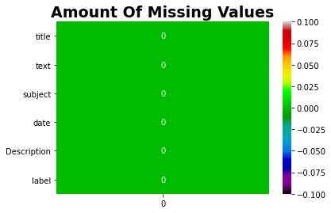

```python
plt.title('Amount Of Missing Values',fontsize=19,fontweight='bold')
sns.heatmap(fake.isna().sum().to_frame(),annot=True,cmap='nipy_spectral')
plt.show()
```

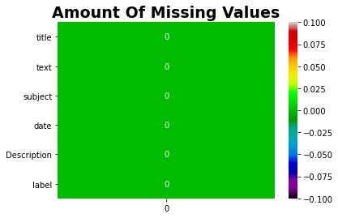

```python
plt.title('Amount Of Missing Values',fontsize=19,fontweight='bold')
sns.heatmap(true.isna().sum().to_frame(),annot=True,cmap='nipy_spectral')
plt.show()
```

#### Creating a new data frame only with the required columns.

```python
true_final = true[['Description', 'label']]
true_final
```

|  | Description | label |
| --- | --- | --- |
| 0 | As U.S. budget fight looms, Republicans flip t... | 1 |
| 1 | U.S. military to accept transgender recruits o... | 1 |
| 2 | Senior U.S. Republican senator: 'Let Mr. Muell... | 1 |
| 3 | FBI Russia probe helped by Australian diplomat... | 1 |
| 4 | Trump wants Postal Service to charge 'much mor... | 1 |
| ... | ... | ... |
| 4995 | U.S. Agriculture secretary nominee submits eth... | 1 |
| 4996 | Trump aides attack agency that will analyze he... | 1 |
| 4997 | Highlights: The Trump presidency on March 12 a... | 1 |
| 4998 | Obama lawyers move fast to join fight against ... | 1 |
| 4999 | Mike Pence to tour Asia next month amid securi... | 1 |

5000 rows × 2 columns

```python
fake_final = fake[['Description', 'label']]
fake_final
```

|  | Description | label |
| --- | --- | --- |
| 0 | Donald Trump Sends Out Embarrassing New Year’... | 0 |
| 1 | Drunk Bragging Trump Staffer Started Russian ... | 0 |
| 2 | Sheriff David Clarke Becomes An Internet Joke... | 0 |
| 3 | Trump Is So Obsessed He Even Has Obama’s Name... | 0 |
| 4 | Pope Francis Just Called Out Donald Trump Dur... | 0 |
| ... | ... | ... |
| 4995 | FBI Warns Republicans: Do Not Leak Clinton Em... | 0 |
| 4996 | Justice Department Announces It Will No Longe... | 0 |
| 4997 | WATCH: S.E. Cupp Destroys Trump Adviser’s ‘Fa... | 0 |
| 4998 | WATCH: Fox Hosts Claim Hillary Has Brain Dama... | 0 |
| 4999 | CNN Panelist LAUGHS In Corey Lewandowski’s Fa... | 0 |

5000 rows × 2 columns

#### Joining both the datasets row wise, and creating the final dataset.

```python
df = pd.concat([true_final, fake_final])
df.head(5)
```

|  | Description | label |
| --- | --- | --- |
| 0 | As U.S. budget fight looms, Republicans flip t... | 1 |
| 1 | U.S. military to accept transgender recruits o... | 1 |
| 2 | Senior U.S. Republican senator: 'Let Mr. Muell... | 1 |
| 3 | FBI Russia probe helped by Australian diplomat... | 1 |
| 4 | Trump wants Postal Service to charge 'much mor... | 1 |

```python
df.tail(5)
```

|  | Description | label |
| --- | --- | --- |
| 4995 | FBI Warns Republicans: Do Not Leak Clinton Em... | 0 |
| 4996 | Justice Department Announces It Will No Longe... | 0 |
| 4997 | WATCH: S.E. Cupp Destroys Trump Adviser’s ‘Fa... | 0 |
| 4998 | WATCH: Fox Hosts Claim Hillary Has Brain Dama... | 0 |
| 4999 | CNN Panelist LAUGHS In Corey Lewandowski’s Fa... | 0 |

```python
df
```

|  | Description | label |
| --- | --- | --- |
| 0 | As U.S. budget fight looms, Republicans flip t... | 1 |
| 1 | U.S. military to accept transgender recruits o... | 1 |
| 2 | Senior U.S. Republican senator: 'Let Mr. Muell... | 1 |
| 3 | FBI Russia probe helped by Australian diplomat... | 1 |
| 4 | Trump wants Postal Service to charge 'much mor... | 1 |
| ... | ... | ... |
| 4995 | FBI Warns Republicans: Do Not Leak Clinton Em... | 0 |
| 4996 | Justice Department Announces It Will No Longe... | 0 |
| 4997 | WATCH: S.E. Cupp Destroys Trump Adviser’s ‘Fa... | 0 |
| 4998 | WATCH: Fox Hosts Claim Hillary Has Brain Dama... | 0 |
| 4999 | CNN Panelist LAUGHS In Corey Lewandowski’s Fa... | 0 |

10000 rows × 2 columns

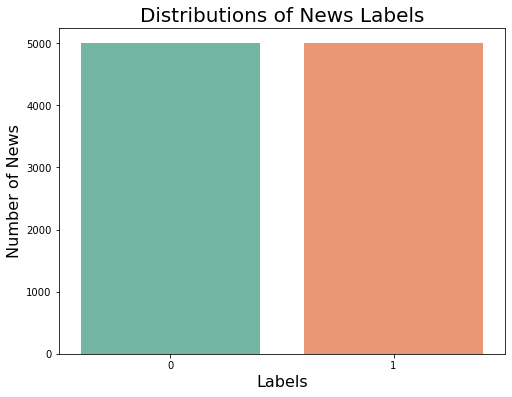

```python
# Final labels Countplot

plt.figure(figsize=(8,6))
sns.countplot(df.label, palette='Set2')
plt.title('Distributions of News Labels',fontsize=20)
plt.xlabel('Labels', fontsize=16)
plt.ylabel('Number of News', fontsize=16)
plt.show()
```

#### Cleaning the dataset:

https://medium.com/analytics-vidhya/data-cleaning-in-natural-language-processing-1f77ec1f6406

- Removing Puntuations
- Stopword Removal
- Lemmatizing the cleaned description column
- Normalizing the data
- Using principal components to extract the features
- Creating X and y training and testing sets

```python
# Importing necessarry libraries to clean the data set
import nltk
import string
import re
```

```python
# Removing Puntuation:

def remove_punct(text):
    text  = "".join([char for char in text if char not in string.punctuation])
    text = re.sub('[0-9]+', '', text)
    return text
```

```python
# Stopword Removal:

from nltk.corpus import stopwords
", ".join(stopwords.words('english'))
STOPWORDS = set(stopwords.words('english'))

def remove_stopwords(text):
    """custom function to remove the stopwords"""
    return " ".join([word for word in str(text).split() if word not in STOPWORDS])
```

```python
# Applying all the defined functions in the data

df['Description'] = df['Description'].apply(lambda x: remove_punct(x))
df['clean_Description'] = df['Description'].apply(lambda text: remove_stopwords(text))
df.head(5)
```

|  | Description | label | clean_Description |
| --- | --- | --- | --- |
| 0 | As US budget fight looms Republicans flip thei... | 1 | As US budget fight looms Republicans flip fisc... |
| 1 | US military to accept transgender recruits on ... | 1 | US military accept transgender recruits Monday... |
| 2 | Senior US Republican senator Let Mr Mueller do... | 1 | Senior US Republican senator Let Mr Mueller jo... |
| 3 | FBI Russia probe helped by Australian diplomat... | 1 | FBI Russia probe helped Australian diplomat ti... |
| 4 | Trump wants Postal Service to charge much more... | 1 | Trump wants Postal Service charge much Amazon ... |

```python
nltk.download('wordnet')
nltk.download('averaged_perceptron_tagger')
```

```
True
```

```python
# Lemmatizing the cleaned description column
# Stemming uses the stem of the word, while lemmatization uses the context in which the word is being used.
# Lemmatization carries out a morphological analysis of the words, the chatbot is able to understand the contextual form of every word and, therefore, it is able to better understand the overall meaning of the entire sentence

from nltk.corpus import wordnet
from nltk.stem import WordNetLemmatizer

lemmatizer = WordNetLemmatizer()
wordnet_map = {"N":wordnet.NOUN, "V":wordnet.VERB, "J":wordnet.ADJ, "R":wordnet.ADV}

def lemmatize_words(text):
    pos_tagged_text = nltk.pos_tag(text.split())
    return " ".join([lemmatizer.lemmatize(word, wordnet_map.get(pos[0], wordnet.NOUN)) for word, pos in pos_tagged_text])

df["Description_lemmatized"] = df["clean_Description"].apply(lambda text: lemmatize_words(text))
df.head(5)
```

|  | Description | label | clean_Description | Description_lemmatized |
| --- | --- | --- | --- | --- |
| 0 | As US budget fight looms Republicans flip thei... | 1 | As US budget fight looms Republicans flip fisc... | As US budget fight loom Republicans flip fisca... |
| 1 | US military to accept transgender recruits on ... | 1 | US military accept transgender recruits Monday... | US military accept transgender recruit Monday ... |
| 2 | Senior US Republican senator Let Mr Mueller do... | 1 | Senior US Republican senator Let Mr Mueller jo... | Senior US Republican senator Let Mr Mueller jo... |
| 3 | FBI Russia probe helped by Australian diplomat... | 1 | FBI Russia probe helped Australian diplomat ti... | FBI Russia probe help Australian diplomat tipo... |
| 4 | Trump wants Postal Service to charge much more... | 1 | Trump wants Postal Service charge much Amazon ... | Trump want Postal Service charge much Amazon s... |

```python
df.head(20)
```

|  | Description | label | clean_Description | Description_lemmatized |
| --- | --- | --- | --- | --- |
| 0 | As US budget fight looms Republicans flip thei... | 1 | As US budget fight looms Republicans flip fisc... | As US budget fight loom Republicans flip fisca... |
| 1 | US military to accept transgender recruits on ... | 1 | US military accept transgender recruits Monday... | US military accept transgender recruit Monday ... |
| 2 | Senior US Republican senator Let Mr Mueller do... | 1 | Senior US Republican senator Let Mr Mueller jo... | Senior US Republican senator Let Mr Mueller jo... |
| 3 | FBI Russia probe helped by Australian diplomat... | 1 | FBI Russia probe helped Australian diplomat ti... | FBI Russia probe help Australian diplomat tipo... |
| 4 | Trump wants Postal Service to charge much more... | 1 | Trump wants Postal Service charge much Amazon ... | Trump want Postal Service charge much Amazon s... |
| 5 | White House Congress prepare for talks on spen... | 1 | White House Congress prepare talks spending im... | White House Congress prepare talk spend immigr... |
| 6 | Trump says Russia probe will be fair but timel... | 1 | Trump says Russia probe fair timeline unclear ... | Trump say Russia probe fair timeline unclear N... |
| 7 | Factbox Trump on Twitter Dec Approval rating... | 1 | Factbox Trump Twitter Dec Approval rating Amaz... | Factbox Trump Twitter Dec Approval rating Amaz... |
| 8 | Trump on Twitter Dec Global Warming The foll... | 1 | Trump Twitter Dec Global Warming The following... | Trump Twitter Dec Global Warming The following... |
| 9 | Alabama official to certify Senatorelect Jones... | 1 | Alabama official certify Senatorelect Jones to... | Alabama official certify Senatorelect Jones to... |
| 10 | Jones certified US Senate winner despite Moore... | 1 | Jones certified US Senate winner despite Moore... | Jones certify US Senate winner despite Moore c... |
| 11 | New York governor questions the constitutional... | 1 | New York governor questions constitutionality ... | New York governor question constitutionality f... |
| 12 | Factbox Trump on Twitter Dec Vanity Fair Hil... | 1 | Factbox Trump Twitter Dec Vanity Fair Hillary ... | Factbox Trump Twitter Dec Vanity Fair Hillary ... |
| 13 | Trump on Twitter Dec Trump Iraq Syria The fo... | 1 | Trump Twitter Dec Trump Iraq Syria The followi... | Trump Twitter Dec Trump Iraq Syria The followi... |
| 14 | Man says he delivered manure to Mnuchin to pro... | 1 | Man says delivered manure Mnuchin protest new ... | Man say deliver manure Mnuchin protest new US ... |
| 15 | Virginia officials postpone lottery drawing to... | 1 | Virginia officials postpone lottery drawing de... | Virginia official postpone lottery draw decide... |
| 16 | US lawmakers question businessman at Trump To... | 1 | US lawmakers question businessman Trump Tower ... | US lawmaker question businessman Trump Tower m... |
| 17 | Trump on Twitter Dec Hillary Clinton Tax Cut... | 1 | Trump Twitter Dec Hillary Clinton Tax Cut Bill... | Trump Twitter Dec Hillary Clinton Tax Cut Bill... |
| 18 | US appeals court rejects challenge to Trump vo... | 1 | US appeals court rejects challenge Trump voter... | US appeal court reject challenge Trump voter f... |
| 19 | Treasury Secretary Mnuchin was sent giftwrappe... | 1 | Treasury Secretary Mnuchin sent giftwrapped bo... | Treasury Secretary Mnuchin send giftwrapped bo... |

```python
!pip install transformers
```

https://www.youtube.com/watch?v=VFp38yj8h3A

In natural language processing most of the data that we handle consists of raw text however machine learning models cannot read or understand text in its raw form they can only work with numbers so the tokenizer's objective will be to translate the text into numbers there are several possible approaches to this conversion and the objective is to find the most meaningful representation we'll take a look at three distinct tokenization algorithms we compare them one to one:

- Word-based tokenizers: https://www.youtube.com/watch?v=nhJxYji1aho
- Character-based tokenizers: https://youtu.be/ssLq_EK2jLE
- Subword-based tokenizers: https://youtu.be/zHvTiHr506c <- We Use as more accuracte,it produces more meaningful subwords

https://www.youtube.com/watch?v=xI0HHN5XKDo